# ggdensity: vignettes

https://github.com/jamesotto852/ggdensity

Maxwell

2022-07-25

# 1 Preparations

## 1.1 Packages

## 1.2 Environment

# 2 Dataset

```r
df <- data.frame("x" = rnorm(1000), "y" = rnorm(1000))
```

# 3 geom_density_2d_filled() vs. geom_hdr()

https://github.com/jamesotto852/ggdensity#geom_density_2d_filled-vsgeom_hdr

While it’s a nice looking plot, it isn’t immediately clear how we should understand it. That’s because geom_density_2d_filled() generates its contours as equidistant level sets of the estimated bivariate density, i.e. taking horizontal slices of the 3d surface at equally-spaced heights, and projecting the intersections down into the plane. So you get a general feel of where the density is high, but not much else. To interpret a contour, you would need to multiply its height by the area it bounds, which of course is very challenging to do by just looking at it.

geom_hdr() tries to get around this problem by presenting you with regions of the estimated distribution that are immediately interpretable:

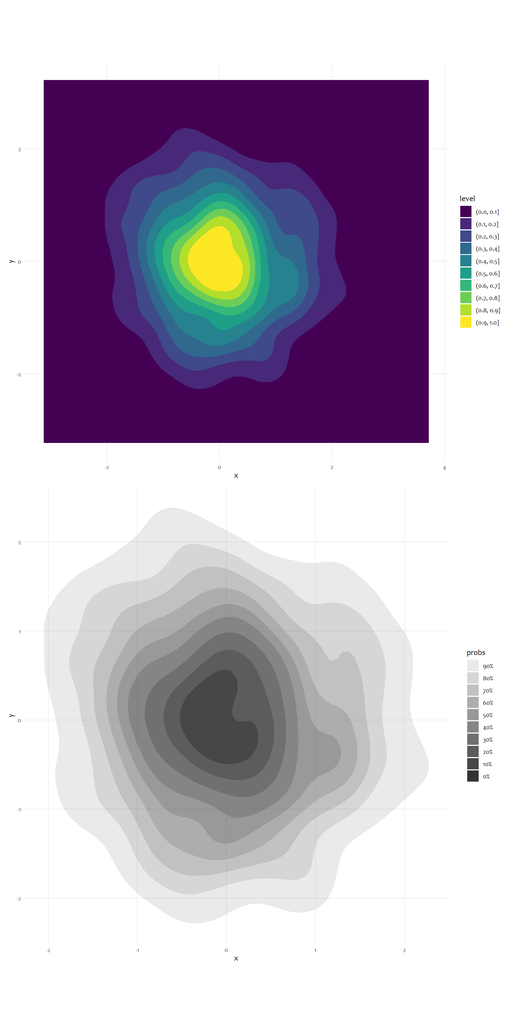

```r
p <- ggplot(df, aes(x, y)) + coord_equal()
p1 <- p + geom_density_2d_filled(contour_var = "ndensity")
p2 <- p + geom_hdr(probs = seq(0, 0.9, 0.1))

p1 / p2
```

# 4 References